# GRADIENTE DESCENDIENTE

Raquel Fort Serra

7/11/2019

Cargamos librerías

```r
library(readr)
library(ISLR)
library(MASS)
library(dplyr)
library(here)
library(testthat)
```

```r
library(ggplot2)
```

Cargamos también la base de datos. La base de datos estña formada por 3 variables y 100 observaciones. Las variables son las siguientes: - label: toma el valor 0 si el estudiante ha sido admitido en la universidad, y 1 si el estudiante sí ha sido admitido. - score-1: es la nota (sobre 100) de la primera prueba - score-2: es la nota (sobre 100)de la segunda prueba En esta prueba vamos a realizar un análisis de regresión logística. La variable dependiente será label y las explicativas score-1 y score-2

```r
library(readr)
data <- read_csv("4_1_data.csv")
```

Hacemos un pequeño análisis de datos

```r
summary(data)
```

```
##     score-1         score-2          label
##  Min.   :30.06   Min.   :30.60   Min.   :0.0
##  1st Qu.:50.92   1st Qu.:48.18   1st Qu.:0.0
##  Median :67.03   Median :67.68   Median :1.0
##  Mean   :65.64   Mean   :66.22   Mean   :0.6
##  3rd Qu.:80.21   3rd Qu.:79.36   3rd Qu.:1.0
##  Max.   :99.83   Max.   :98.87   Max.   :1.0
```

```r
colSums(is.na(data))
```

```
## score-1 score-2   label
##       0       0       0
```

Renombramos las variables para trabajar de forma más cómoda

```r
data <- rename(data,"score1" = `score-1`)
data <- rename(data,"score2" = `score-2`)
```

Nos hacemos una idea visual de cómo se distribuyen los datos.

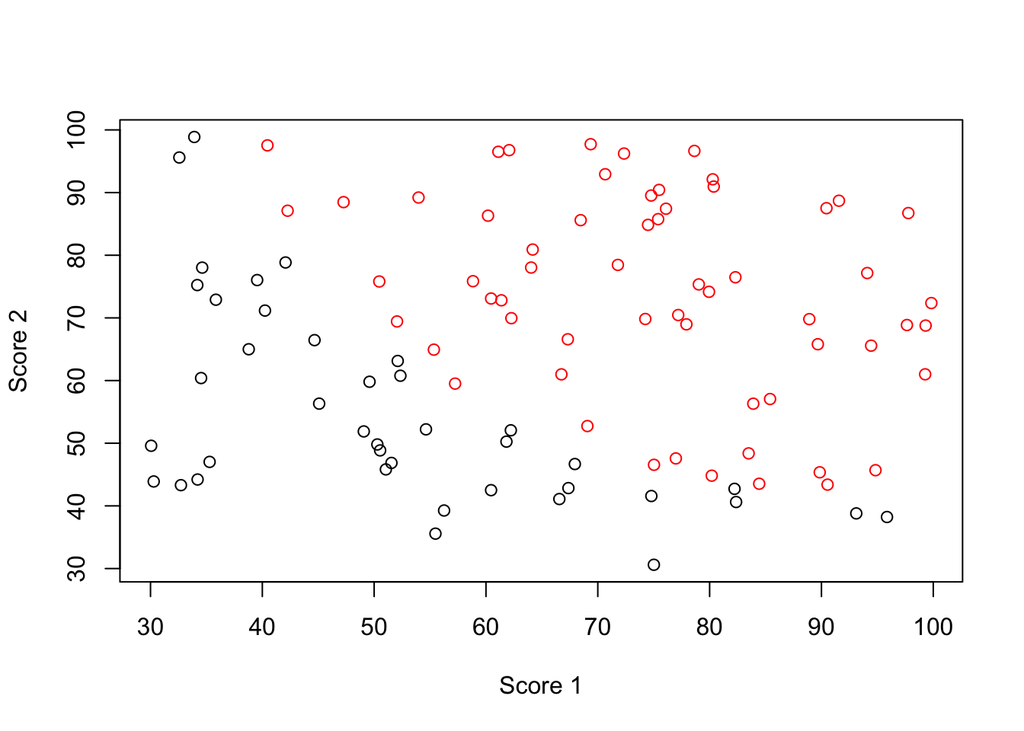

```r
plot(data$score1, data$score2, col = as.factor(data$label), xlab = "Score 1", ylab = "Score 2")
```

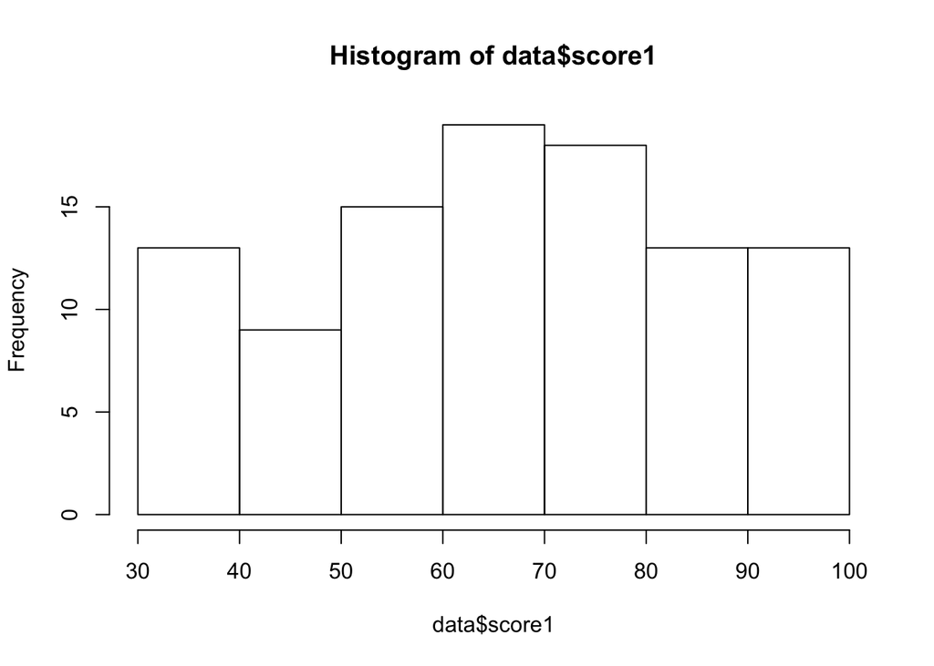

```r
#poner titulos
hist(data$score1)
```

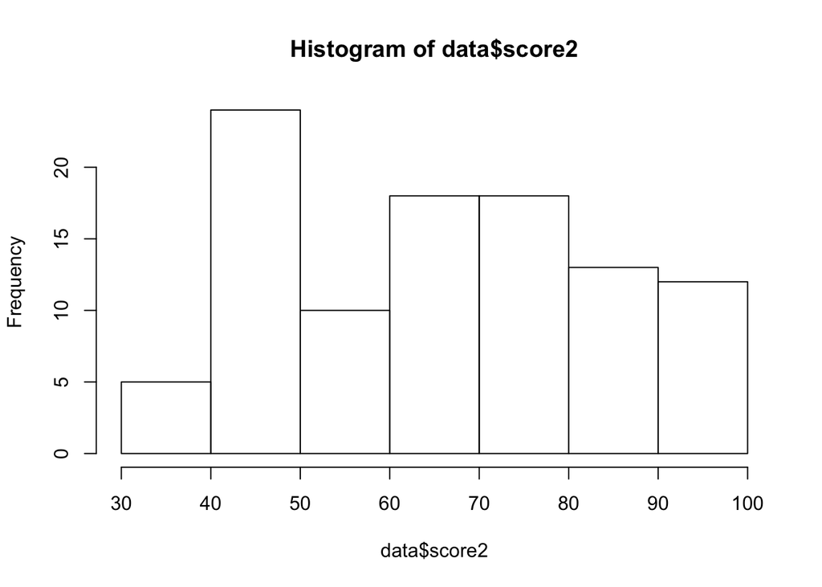

```r
hist(data$score2)
```

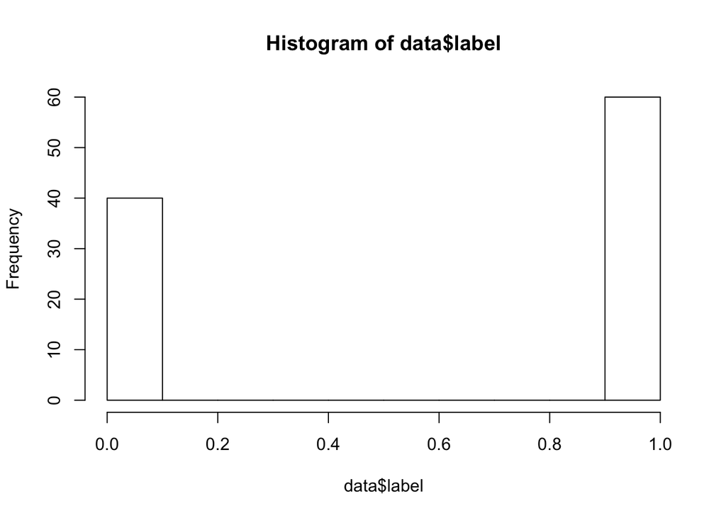

```r
hist(data$label) #esta es la que nos interesa
```

Creamos la función Sigmoide y la de Costes.

La funcion Sigmoide nos facilita la interpretacion de los datos y la toma de decisiones. La función de costes es nuestra función objetivo, queremos minimizarla para de esta forma minimzar el error que se comete al estimar si un estudiante es admitido en la universidad o no (que es lo que representa en este caso la función de costes)

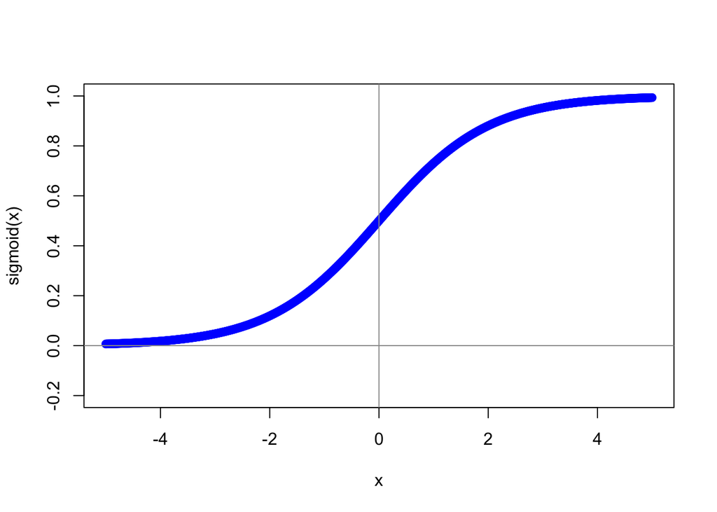

```r
sigmoid <- function(x) {
  1 / (1 + exp(-x))
}
# grafico de la sigmoide
 x<- seq(-5,5,0.01)
 plot(x, sigmoid(x), col="blue", ylim= c(-.2,1))
 abline(h=0, v=0, col = "gray60")
```

```r
costFunction <- function(parameters, X, Y) {
  n <- nrow(X)
  g <- sigmoid(X %*% parameters)
  J <- (1/n) * sum((-Y * log(g)) - ((1 - Y) * log(1 - g)))
  return(J)
}
```

1. Test the TestGradientDescent function with the training set (4_1_data.csv). Obtain the confusion matrix.

Dataset de entrenamiento y test

```r
# Dividimos la muestra en training y test
set.seed(1000)
n = nrow(data)
id_train <- sample(1:n, 0.80*n)  #80 % para el train y por lo tanto 20% para test.
data.train <- data[id_train,]
data.test <- data[-id_train,]
```

Creamos las variables de entrenamiento y test.

```r
# Matrices de Train
Xtrain <- as.matrix(data.train[,c(1,2)])
Xtrain <- cbind(rep(1,nrow(Xtrain)),Xtrain)
Ytrain <- as.matrix(data.train$label)
# Matrices de Test
Xtest <- as.matrix(data.test[,c(1,2)])
Xtest <- cbind(rep(1,nrow(Xtest)),Xtest)
Ytest <- as.matrix(data.test$label)
```

Calculamos el coste inicial con los parametros cero (= 0.69). Lo que queremos es reducir el porcentaje de ese coste inicial.

```r
#fijamos nuestro vector de parámetros inicial definido como ceros
initial_parameters <- rep(0, ncol(Xtrain))
#calculamos el coste inicial

initial_cost <- costFunction(initial_parameters, Xtrain, Ytrain)
initial_cost
```

```
## [1] 0.6931472
```

```r
# El error que me saldría si fijo los parámetros a 0. Estás acertando que no entre nadie a la universidad.
print(paste("El coste inicial de la función es: ",
              convergence <- c(costFunction(initial_parameters, Xtrain, Ytrain)), sep = ""))
```

```
## [1] "El coste inicial de la función es: 0.693147180559945"
```

obtenemos el número de iteraciones óptimo, para ello vamos a crear una funcion que represente la influencia de las iteraciones en el numero optimo de parametros.

```r
CostIterations = function(iterations){
        position <- NULL
        cost <- NULL
        i <- 0
        for (i in (1 : iterations)) {
                i <- i + 1
                param_optimiz <- optim(par = initial_parameters, fn = costFunction, X = Xtrain, Y = Ytrain, control = list(maxit = i))
                parametres <- param_optimiz$par
                position <- c(position,i)
                cost <- c(cost,costFunction(parametres,Xtrain,Ytrain))
        }
        df_cost <- data.frame(position,cost)

        print(plot(df_cost$position,df_cost$cost))

        return(df_cost)
}
```

```r
results <- CostIterations(150)
```

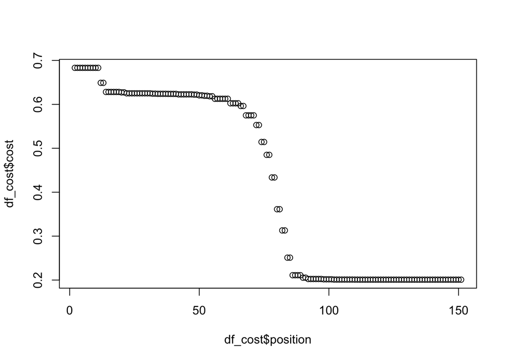

```r
df_iter_cost <- data.frame(results$position,results$cost)
```

Podemos ver que el numero de iteraciones que minimiza el coste es 142 y que el valor final de la función de costes es 0.2008397 (inferior al inicial)

```r
df_iter_cost[df_iter_cost$results.cost == min(df_iter_cost$results.cost),]
```

|  | results.position | results.cost |
| --- | --- | --- |
| 141 | 142 | 0.2008397 |
| 142 | 143 | 0.2008397 |
| 143 | 144 | 0.2008397 |
| 144 | 145 | 0.2008397 |
| 145 | 146 | 0.2008397 |
| 146 | 147 | 0.2008397 |
| 147 | 148 | 0.2008397 |
| 148 | 149 | 0.2008397 |
| 149 | 150 | 0.2008397 |
| 150 | 151 | 0.2008397 |

Ahora creamos la funcion TestGradientDescent con las funciones que hemos creado anteriormente

```r
TestGradientDescent <- function(iterations, X, Y){

        param_optimiz <- optim(par = initial_parameters, fn = costFunction,
                                        X = Xtrain, Y = Ytrain, control = list(maxit = iterations))
        print(param_optimiz)

        parameters <- param_optimiz$par

        print(paste("Final Cost Function value: ",
                    convergence <- c(costFunction(parameters, X, Y)), sep = ""))

        return(parameters)

}
TestGradientDescent(150, Xtrain, Ytrain)
```

```
## $par
## [1] -24.3756053   0.1989812   0.1963604
##
## $value
## [1] 0.2008397
##
## $counts
## function gradient
##      152       NA
##
## $convergence
## [1] 1
##
## $message
## NULL
##
## [1] "Final Cost Function value: 0.200839716494778"
```

```
## [1] -24.3756053   0.1989812   0.1963604
```

Con esta función vemos los parámetros óptimos que minimizan nuestra funcion de costes.

Ahora comprobamos que los resultados son correctos utilizando la funcion “test_that”

```r
parameters <- TestGradientDescent(150, X = Xtrain, Y = Ytrain)
```

```
## $par
## [1] -24.3756053   0.1989812   0.1963604
##
## $value
## [1] 0.2008397
##
## $counts
## function gradient
##      152       NA
##
## $convergence
## [1] 1
##
## $message
## NULL
##
## [1] "Final Cost Function value: 0.200839716494778"
```

```r
# probability of admission for student (1 = b, for the calculos)
new_student <- c(1,10,83)
print("Probability of admission for student:")
```

```
## [1] "Probability of admission for student:"
```

```r
print(prob_new_student <- sigmoid(t(new_student) %*% parameters))
```

```
##             [,1]
## [1,] 0.002265077
```

```r
test_that("Test TestGradientDescent",{
  parameters <- TestGradientDescent(150, X = Xtest, Y = Ytest)
  new_student <- c(1,10,83)
  prob_new_student <- sigmoid(t(new_student) %*% parameters)
  print(prob_new_student)
  expect_equal(as.numeric(round(prob_new_student, digits = 5)), 0.00227)

})
```

```
## $par
## [1] -24.3756053   0.1989812   0.1963604
##
## $value
## [1] 0.2008397
##
## $counts
## function gradient
##      152       NA
##
## $convergence
## [1] 1
##
## $message
## NULL
##
## [1] "Final Cost Function value: 0.214850812818651"
##             [,1]
## [1,] 0.002265077
```

Vemos que la probabilidad de que un estudiante entre en la universidad con las notas asumidas es de 0.002265077.

Ahora veremos la Matriz de confusión y el porcentaje de acierto.

Primero vamos a hacer una prediccion con la muestra test para hacer la matriz de confusión.

```r
predic_prob <- sigmoid(Xtest %*% parameters)
# probabilidades
predic_prob <- data.frame(predic_prob)
```

Y ahora creamos la funcion que calcule la matriz de confusion en funcion de la prediccion de probabilidad que hemos calculado anteriormente.

```r
ConfMatrix = table(Ytest, predic_prob$predic_prob, dnn = c("Truth","Predicted"))
ConfMatrix
```

```
##      Predicted
## Truth 0.00726167670052539 0.00877718176066558 0.0180018319200632
##     0                   1                   1                  1
##     1                   0                   0                  0
##      Predicted
## Truth 0.0372728460247909 0.116437201255972 0.171135840981989
##     0                  1                 1                 1
##     1                  0                 0                 0
##      Predicted
## Truth 0.209064225453136 0.214177048195357 0.37252839339022
##     0                 1                 0                1
##     1                 0                 1                0
##      Predicted
## Truth 0.570468562694506 0.592533673452895 0.850323852779566
##     0                 0                 1                 0
##     1                 1                 0                 1
##      Predicted
## Truth 0.96974095467448 0.989514124333402 0.995110269760191
##     0                0                 0                 0
##     1                1                 1                 1
##      Predicted
## Truth 0.997860578419091 0.999106957329849 0.999109904572615
##     0                 0                 0                 0
##     1                 1                 1                 1
##      Predicted
## Truth 0.999641032424875 0.999964611785262
##     0                 0                 0
##     1                 1                 1
```

```r
accuracy <- 100*sum(diag(table(Ytest, predic_prob$predic_prob)))/sum(table(Ytest, predic_prob$predic_prob)) #incluimos la accuracy para que tambien nos la devuelva

        print(paste("El accuracy es: ", accuracy))
```

```
## [1] "El accuracy es:  5"
```

La matriz de confusion evalúa la precision y exactitud del modelo.

2. Obtain a graph representing how the cost function evolves depending of the number of iterations.

presentamos la funcion de coste mínima, cuantas más iteraciones más fácil encontrar la funcion mínima de coste

```r
results <- CostIterations(400)
```

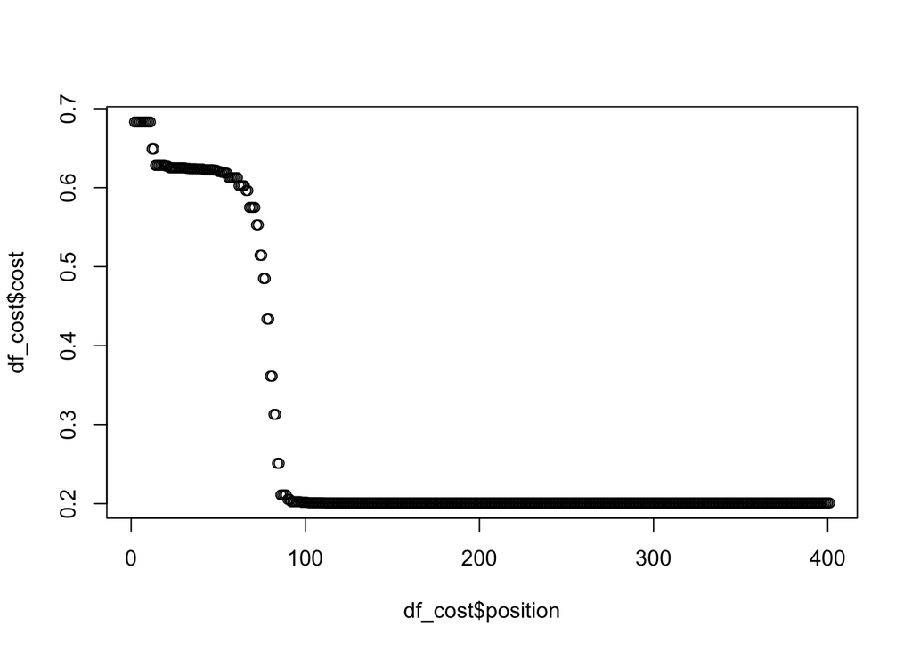

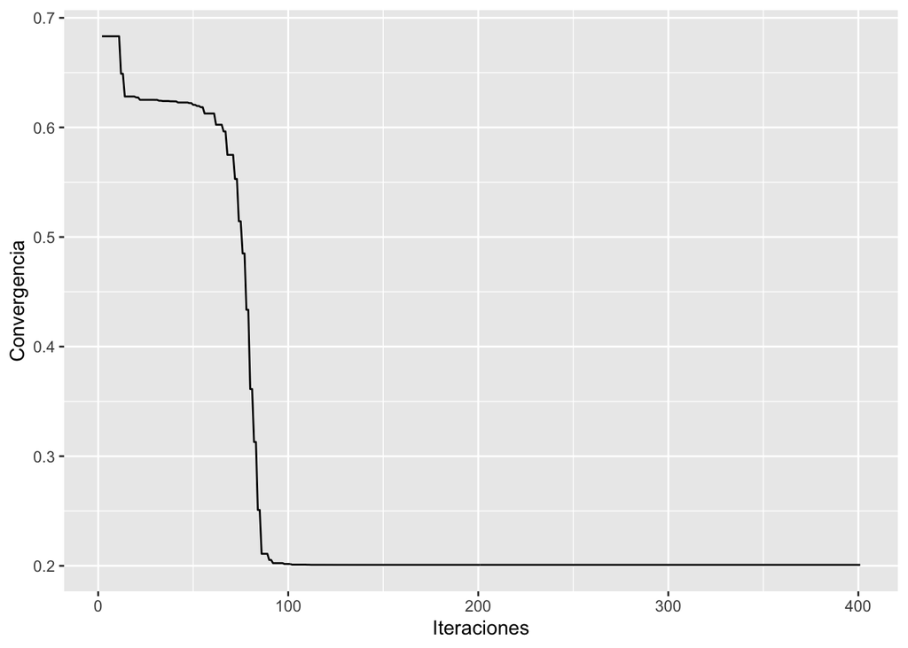

```r
ggplot(results,aes(x = results$position, y = results$cost)) + geom_line() + xlab('Iteraciones') + ylab('Convergencia')
```

3. Explore other options using the optim function (see the methods section of the documentation). Explore other ways in R for estimating the Gradient Descent.

```r
args(optim)
```

```
## function (par, fn, gr = NULL, ..., method = c("Nelder-Mead",
##     "BFGS", "CG", "L-BFGS-B", "SANN", "Brent"), lower = -Inf,
##     upper = Inf, control = list(), hessian = FALSE)
## NULL
```

Los métodos que nos muestra la función son: method = c(“Nelder-Mead”, “BFGS”, “CG”, “L-BFGS-B”, “SANN”, “Brent”). Utilizando estos diferentes métodos podemos obtenemos distintos parámetros para los cuales la función de coste es la mínima.

```r
TestGradientDescent2 <- function(iterations, X, Y, method){

        param_optimiz <- optim(par = initial_parameters, fn = costFunction,
                                        X = Xtrain, Y = Ytrain,
                               control = list(maxit = iterations), method = method)

        parameters <- param_optimiz$par


        return(parameters)

}
TestGradientDescent2(150, Xtrain, Ytrain, "BFGS")  #nos muestra los parámetros óptimos al utilizar el método BFGS
```

```
## [1] -24.2551801   0.1980280   0.1953791
```

```r
TestGradientDescent2(150, Xtrain, Ytrain, "CG")  #nos muestra los parámetros óptimos al utilizar el método CG
```

```
## [1] -0.0132706717  0.0113908180  0.0006838295
```